```python
import warnings
warnings.simplefilter(action='ignore', category=FutureWarning)

import rs_utils, utils, irt, pandas as pd, seaborn as sns, math, numpy as np, matplotlib.pyplot as plt
from scipy.stats import pearsonr
from pathlib import Path

quizzes, answers = rs_utils.load_answers()
answers = pd.DataFrame(answers).sort_values('timestamp')
sns.set()

def schema_for_id(q):

    df = answers
    row = df[df.questionId == q].iloc[-1]
    return quizzes.schema(row.quizName, row.commitHash)['questions'][row.question]

def print_sch(q):
    utils.fmt_schema(schema_for_id(q))
```

```python
import importlib
importlib.reload(utils)
importlib.reload(irt)
```

```
<module 'irt' from '/Users/will/Code/rust-book-backend/notebooks/irt.py'>
```

# Analysis

This notebook contains the key results that will form the purely descriptive part of the paper (i.e. not the interventions).

## 1. Reader Characteristics

**RQ1. What do the quizzes tell us about the Rust Book readers?**

Given that we do not have any demographic data on our readers, we will primarily look at this question in terms of the amount of effort put in by each reader.

First, we can count how many questions were answered by each reader:

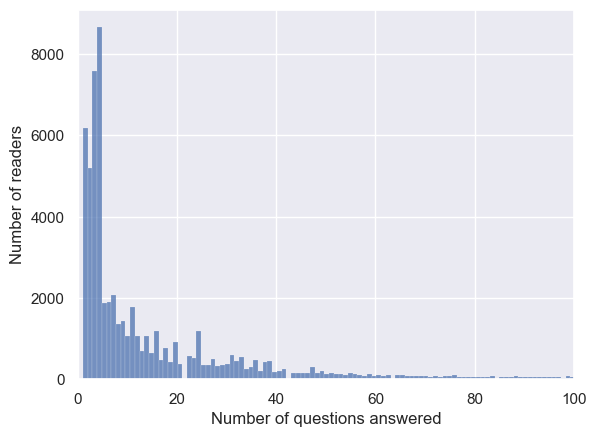

```python
ax = sns.histplot(answers.groupby('sessionId').size())
ax.set_xlim(0, 100)
ax.set_ylabel('Number of readers')
_ = ax.set_xlabel('Number of questions answered')
```

Many readers answered fewer than 10 questions, meaning they tried the book and gave up. Let's focus on the readers who stuck with it — call them "triers", defined as "a reader who answered more than the average number of questions".

```python
answer_counts = answers.groupby('sessionId').size()
avg_answered = answer_counts.mean()
triers = answer_counts[answer_counts >= avg_answered].index
answers_triers = answers[answers.sessionId.isin(triers)]
print(f'Avg # of answers: {avg_answered:.3f}, number of triers: {len(triers)}')
```

```
Avg # of answers: 18.236, number of triers: 17515
```

How well did the triers do on our questions? Here's the distribution of average scores:

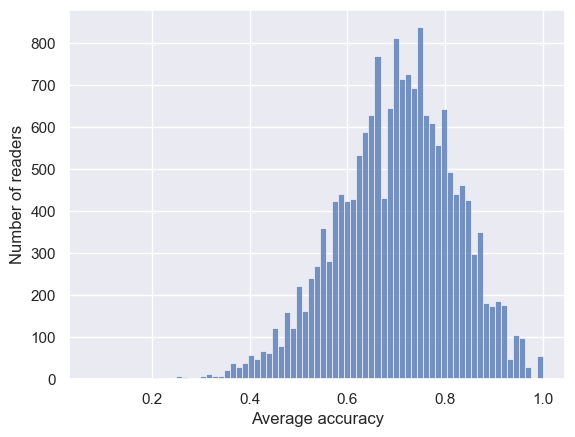

```python
trier_scores = answers_triers.groupby('sessionId').correct.mean()
ax = sns.histplot(trier_scores)
ax.set_xlabel('Average accuracy')
_ = ax.set_ylabel('Number of readers')
```

So your average reader (note: *trier*) gets between 60% and 80% correct, with a bit of a tail to the bottom of the accuracy distribution.

We can also look at how far readers make it into the book. This chart shows a histogram of the last chapter where a user answered a question. Note that the Rust Book has quizzes until Chapter 19.

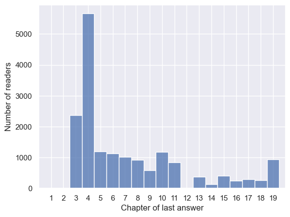

```python
last_chapter = answers_triers.groupby('sessionId').chapter.max()
ax = sns.histplot(last_chapter, discrete=True)
ax.set_xlim(0, 20)
ax.set_xticks(range(1, 20))
ax.set_xticklabels(range(1, 20))
ax.set_xlabel('Chapter of last answer')
_ = ax.set_ylabel('Number of readers')
```

> Note to Shriram: in case you're worried, no, this wasn't caused by the ownership intervention. Dropout rates were similar before our intervention as well.

```python
reached_end = (last_chapter == 19).sum()
frac_reaching_end = reached_end / len(last_chapter)
print(f'Fraction that reach the end of the book: {frac_reaching_end:.3f}')
print(f'Absolute number that reach the end: {reached_end}')
```

```
Fraction that reach the end of the book: 0.053
Absolute number that reach the end: 929
```

So out of 65,000 people who picked up the Rust Book, only 929 actually made it to the end!

**The main takeaway:** there's a huge drop-off from dabblers to triers, and from triers to completers. And tricky language concepts like ownership serve as a fall-off point for many readers.

## 2. Question Characteristics

**RQ2. What do readers' answers tell us about the Rust Book questions?**

First, we need to generate a summary dataframe with one row per question. We will only look at answers from triers, and we will only look at questions that have at least 30 responses.

```python
answers_triers = answers_triers[~answers_triers.questionId.isna()]
all_qs = answers_triers.questionId.unique().tolist()
q_accuracy = answers_triers.groupby('questionId').correct.mean()
q_counts = answers_triers.groupby('questionId').size()

def compute_corr(q):
    df = answers_triers[answers_triers.questionId == q]
    return pearsonr(df.correct, trier_scores[df.sessionId]).statistic

q_df = pd.DataFrame([{
    'id': q,
    'len': quizzes.length(q),
    'acc': q_accuracy[q],
    'r': compute_corr(q),
    'N': q_counts[q]
} for q in all_qs if q_counts[q] > 30])

print(f'Total number of questions: {len(q_df)}')
```

```
Total number of questions: 211
```

### 2.1 Question Difficulty

We can get a sense of how hard the questions are by looking at a distribution of per-question accuracy:

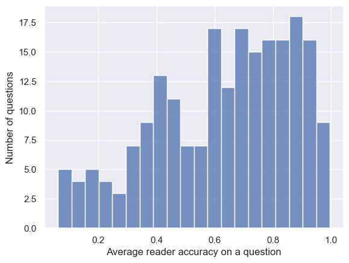

```python
ax = sns.histplot(q_df.acc, bins=20)
ax.set_xlabel('Average reader accuracy on a question')
_ = ax.set_ylabel('Number of questions')
```

There are questions of all levels of difficulty — more spread out than the score distribution above — but still centered around 0.7 - 0.8.

As the designers of these questions, we are fairly satisfied with this distribution. The questions should pose some challenge but not be impossible, as that would be demotivating to readers. We expect most sufficiently complex questions to cap out around 80-90% given the inherent variance of random users answering questions. However, questions below 50% are worth investigating to improve user performance — we will return to this issue in the next section about interventions.

To give a concrete sense of question difficulty, these are the three easiest questions:

```python
for _, row in q_df.sort_values('acc', ascending=False).iloc[:3].iterrows():
    print(f'ACCURACY {row.acc:.3f}')
    print_sch(row.id)
    utils.print_sep()
```

```
ACCURACY 0.996
QUESTION TYPE: Tracing
PROMPT:
fn foo(x: &i32) {
  println!("{x}");
}

fn main() {
  let x = null;
  foo(x);
}

ANSWER: does NOT compile

====================

ACCURACY 0.993
QUESTION TYPE: ShortAnswer
PROMPT:
What is the keyword used after `let` to indicate that a variable can be mutated?
ANSWER: mut

====================

ACCURACY 0.989
QUESTION TYPE: MultipleChoice
PROMPT:
Which kind of programming error is a lifetime supposed to prevent?
✓ Using a reference to an object after its memory has been freed
✗ Using the result of a fallible computation before checking for the possibility of error
✗ Indexing past the bounds of an array (buffer overflow)
✗ Not allocating enough memory for an object

====================
```

- The first question is Rust's selling point, so most people get there's no null pointers.
- The second question is pure syntax, which most people can pick up.
- The third question is more conceptual, but the book seems to do a good job at conveying it.

And the three hardest questions:

```python
for _, row in q_df.sort_values('acc', ascending=True).iloc[:3].iterrows():
    print(f'ACCURACY {row.acc:.3f}')
    print_sch(row.id)
    utils.print_sep()
```

````
ACCURACY 0.061
QUESTION TYPE: ShortAnswer
PROMPT:
Consider a program with the following unit test:

```
#[test]
fn test_the_logger() { /* ... */ }

#[test]
fn test_the_database() { /* ... */ }

#[test]
fn test_logger_and_database() { /* ... */ }
```

What is the *shortest* string you can pass to `cargo test <the_string>` such that *only* `test_the_logger` and `test_the_database` are executed?

ANSWER: h

====================

ACCURACY 0.068
QUESTION TYPE: MultipleChoice
PROMPT:
Which of the following are situations where using `unsafe` code (or a safe wrapper around `unsafe` code)
is an idiomatic method for working around the borrow checker?

✓ Getting two mutable references to disjoint indices in an array
✓ Allowing values to be uninitialized when they are not being read
✓ Having a reference to one field of a struct sit in another field of the same struct
✗ Returning a pointer to a stack-allocated variable out of a function

====================

ACCURACY 0.070
QUESTION TYPE: MultipleChoice
PROMPT:
Say we have a function that moves a box, like this:
```
````

[output cut: 23 more lines]

````
let b = Box::new(0);
move_a_box(b);
let b2 = b;
```

✗ ```
let b = Box::new(0);
let b2 = b;
println!("{}", b);
move_a_box(b2);
```

✗ None of the above

====================
````

- The first question is hard in a trivial way — computing a shortest discriminating substring.
- The second question is hard in both a conceptual and combinatorial way. The user must pick a subset of the correct answers, and it's easy to miss one.
- The third question is similary hard in a conceptual and combinatorial way. This deals with counterfactual behavior that isn't expressible in normal Rust.

### 2.2 Question Discrimination via Correlation

Hard Question #1 illustrates how a question can be *difficult* but not *interesting*. That is, if a reader gets it wrong, that doesn't tell us much about whether they actually understand Rust itself. (We intentionally added it to the book more as a silly puzzle than a conceptual challenge.)

We are interested in which questions are *indicative of a general understanding of Rust.* That is, if readers answer these questions correctly, then we feel they have a solid grasp on Rust fundamentals overall. In psychometrics, this quality is usually called "discrimination", as in a question's ability to discriminate between high-ability and low-ability students. Question discrimination is valuable on two dimensions:

1. It is useful to know whether a question is discriminating *per se*. For example, we can use discriminating questions to construct short tests that quickly and effectively screen for Rust expertise. This could be useful as a pre-test for a Rust course, or as an interview for a Rust job.
2. It is useful to know the qualities that make a question discriminating (or not). These qualities tell us about the concepts that are most essential to Rust, and they can potentially inform the design of good quiz questions for other programming languages as well.

Ideally, we might compare quiz question performance with an ecologically-valid metric such as ability to work within a real Rust codebase. But we do not have such data. A common alternative in psychometrics is to compare performance on an individual question against performance on the entire set of questions. The simplest form of this comparison is the correlation (Pearson's $r$) of a person's answer to a question (i.e., 0 or 1) against their test score (i.e., in the interval [0, 1]).

> A caveat: average scores are computed for "triers", but unlike a standard testing setup, most readers did not answer all questions. So a reader's average score is their score up to the point where they stopped answering questions, not until the end of the test.

The distribution of question correlations is plotted in a histogram below.

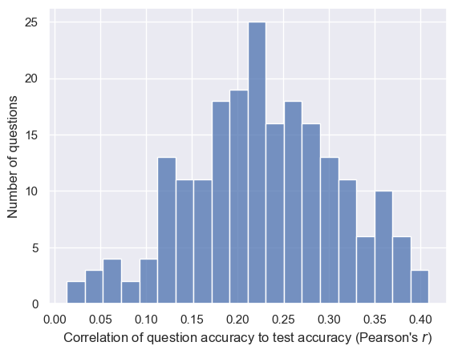

```python
ax = sns.histplot(q_df.r, bins=20)
ax.set_xlabel('Correlation of question accuracy to test accuracy (Pearson\'s $r$)')
_ = ax.set_ylabel('Number of questions')
```

These are the three lowest correlation questions:

```python
for _, row in q_df.sort_values('r', ascending=True).iloc[:3].iterrows():
    print(f'CORRELATION {row.r:.3f}')
    print_sch(row.id)
    utils.print_sep()
```

````
CORRELATION 0.013
QUESTION TYPE: ShortAnswer
PROMPT:
Imagine using a third-party function whose implementation you don't know, but whose type signature is this:

```
fn mystery<T>(x: T) -> T {
  // ????
}
```

Then you call `mystery` like this:

```
let y = mystery(3);
```

Assuming `mystery` uses no unsafe code, then the value of `y` must be :

ANSWER: 3

====================

CORRELATION 0.033
QUESTION TYPE: MultipleChoice
PROMPT:
**Program 2:**

```ide
/// Adds a Display-able object into a vector of
/// Display trait objects
use std::fmt::Display;
fn add_displayable<T: Display>(
    v: &mut Vec<Box<dyn Display>>,
    t: T
) {
    v.push(Box::new(t));
}
```

````

[output cut: 13 more lines]

````

```rust
fn extract(b: &Box<i32>) -> i32 {
    let b2: Box<i32> = *b;
    *b2
}
```

Imagine that the borrow checker did not reject this function.
Determine whether there exists an input such that the function would cause undefined behavior if executed on that input.

✓ This function COULD cause undefined behavior
✗ This function could NOT cause undefined behavior

====================
````

- The first question is again silly, in that it tests for understanding of Wadler's theorems-for-free ideas which are not taught in the text. It turns out that understanding Wadler has no correlation with understanding Rust, which is somewhat ironic.
- The second question is a compiler error involving advanced features like trait objects and lifetime parameters. This question is certainly difficult, but interestingly it is not discriminating.
- The third question asks about undefined behavior involving double frees due to a move-through-a-reference. Again, a difficult question, but the ability to answer is correctly does not seem to correlate with overall test performance.

We can also look at the three highest correlation questions:

```python
for _, row in q_df.sort_values('r', ascending=False).iloc[:3].iterrows():
    print(f'CORRELATION {row.r:.3f}')
    print_sch(row.id)
    utils.print_sep()
```

```
CORRELATION 0.409
QUESTION TYPE: Tracing
PROMPT:
use std::rc::Rc;
struct Example;
impl Drop for Example {
    fn drop(&mut self) {
        println!("drop");
    }
}
fn main() {
    let x = Rc::new(Example);
    let y = Rc::clone(&x);
    println!("A");
    drop(x);
    println!("B");
    drop(y);
    println!("C");
}

ANSWER: DOES compile, stdout is:
  A
  B
  drop
  C


====================

CORRELATION 0.403
QUESTION TYPE: MultipleChoice
PROMPT:
Consider implementing a trait `Trait` for a type `T`. In which of the following situations
do you need to wrap `T` in a newtype?

✓ `Trait` is defined in an external crate and `T` is defined in an external crate
✗ `Trait` is defined in the local crate and `T` is defined in an external crate
✗ `Trait` is defined in an external crate and `T` is defined in the local crate
✗ `Trait` is defined in the local crate and `T` is defined in the local crate

```

[output cut: 11 more lines]

````
}
fn main() {
  let mut v = vec![1, 2, 3];
  copy_to_prev(&mut v, 1);
}
```

Which of the following best describes the undefined behavior that could occur if this program were allowed to execute?

✓ There is no undefined behavior in this program
✗ The assignment `*n` is a use of freed memory
✗ The borrow `&mut v[i]` creates a pointer to freed memory
✗ The read of `v[i - 1]` is a use of freed memory

====================
````

- The first question involves the semantics of reference-counted pointers, and when destructors are executed.
- The second question asks about the "coherence" rules that dictate when it's permitted to implement a trait for a type.
- The third question is similar to the Low Correlation Question #3, except this time it asks about a program that does not actually have undefined behavior.

In terms of difficulty, it was relatively clear what made questions easy or hard. Discrimination seems to be more subtle — beyond trivial examples like the Theorems-for-Free Question, it less obvious why a question falls into one bucket or the other. As a first pass, we did a thematic analysis of the core concepts involved in each of the 20 highest and 20 lowest discrimination questions. Below is the statistics for all codes generated:

```python
high_discrim = pd.read_csv('../data/discrim-high.csv', header=None).unstack().value_counts()
low_discrim = pd.read_csv('../data/discrim-low.csv', header=None).unstack().value_counts()

codes = set(high_discrim.index) | set(low_discrim.index)
discrim_df = pd.DataFrame([{
    "code": code,
    "low": low_discrim.get(code, 0),
    "high": high_discrim.get(code, 0),
} for code in codes])
discrim_df["delta"] = discrim_df.high - discrim_df.low
discrim_df.sort_values("delta")
```

|  | code | low | high | delta |
| --- | --- | --- | --- | --- |
| 15 | Does not compile | 6 | 0 | -6 |
| 8 | Lifetimes | 6 | 0 | -6 |
| 5 | Syntax | 2 | 0 | -2 |
| 12 | Variables | 2 | 0 | -2 |
| 18 | Trait objects | 1 | 0 | -1 |
| 16 | Double free | 1 | 0 | -1 |
| 14 | Design knowledge | 4 | 3 | -1 |
| 20 | Enums | 1 | 0 | -1 |
| 17 | Unrelated | 1 | 0 | -1 |
| 22 | Sized bounds | 1 | 0 | -1 |
| 21 | Traits | 2 | 2 | 0 |
| 4 | Drop | 1 | 1 | 0 |
| 10 | Moves | 2 | 2 | 0 |
| 19 | Ownership | 0 | 1 | 1 |
| 6 | Memory layout | 0 | 1 | 1 |
| 2 | Collections | 0 | 1 | 1 |
| 1 | Integers | 0 | 1 | 1 |
| 13 | Scopes | 0 | 1 | 1 |
| 0 | Permissions | 0 | 2 | 2 |
| 11 | Modules | 0 | 2 | 2 |
| 9 | Unsafe | 0 | 2 | 2 |
| 23 | Incompleteness | 0 | 2 | 2 |
| 3 | Undefined behavior | 2 | 5 | 3 |
| 7 | References | 2 | 6 | 4 |

The most notable trend is that two (overlapping) kinds of questions exclusively appeared in the low correlation category:

- **Lifetimes:** questions that focus on lifetime polymorphism, inference, and errors.
- **Does not compile:** a specific type of question — Tracing questions where the answer is "does not compile".

Most of the high correlation questions dealt with the other aspects of ownership:

- **References:** questions about immutable or mutable references, both at compile-time and runtime.
- **Undefined behavior:** questions about the kind of undefined behavior a program might have.
- **Incompleteness:** questions about undefined behavior where a program is rejected but actually safe.
- **Unsafe:** questions about the `unsafe` keyword.

We must be careful while interpreting these numbers. For instance, the book asks many more questions about e.g. ownership than modules, so it would be inappropriate to deduce just from these numbers that ownership is more central to Rust than modules (even though most would probably argue as such).

Nonetheless, a preliminary interpretation suggests that:

- Understanding of ownership is, in fact, a discriminating skill for understanding Rust.
- Questions about the *purpose* and *concepts* of ownership (undefined behavior, incompleteness) are far more discriminatory than questions about the *mechanics* of ownership (lifetimes, compilation failures).

More broadly, this suggests a prescription: those seeking to write quiz questions about type systems should consider limiting the number of questions that ask readers to "simulate the type checker" in their heads, especially questions that may be seen as a "gotcha" (you thought this would compile, but it actually doesn't for a subtle reason!). A more useful kind of question is to *tell* readers that something does or doesn't compile, and ask a more conceptual question about the reasons why or how.

### 2.3 Question Discrimination via IRT

Correlation provides a "coarse-grained" metric of question discrimination, in the sense that it does not account for the difficulty or guess-ability of the question. Another common model for question discrimination comes from item response theory (IRT). The high-level idea of iRT is to model a question as a function that takes as input some features of the reader and the item, and returns as output the probability that the reader will answer the item correctly. Or formally: for an item $i$ and a subject $j$ with features $Z^\mathsf{item}_i$ and $Z^\mathsf{subj}_j$, let $C_{i,j}$ be a random variable for whether $j$ answers $i$ correctly. IRT is a model for:

$$ P[C_{i,j} \mid Z^\mathsf{item}_i, Z^\mathsf{subj}_j] $$

There are a number of models in the literature, but a common one we use here is the "three-parameter logistic model". In this model, $Z^\mathsf{item}_i = [\alpha_i, \beta_i, \lambda_i]$ and $Z^\mathsf{subj}_j = [\theta_j]$ and the probability is modeled as:

$$ P[C_{i,j}] = \lambda_i + (1 - \lambda_i) * \sigma(\alpha_i * (\theta_j - \beta_i)) $$

These parameters are often interpreted as having the following meanings:

- $\alpha_i$ is the discrimination factor. The higher $\alpha_i$ is, the steeper the sigmoid curve, meaning the more discriminative a question is *at a given level of difficulty*.
- $\beta_i$ is the difficulty factor. The higher $\beta_i$ is, the lower $P[C_{i, j}]$ for a given $\theta_j$.
- $\lambda_i$ is the baseline factor. It accounts for the probability of guessing.
- $\theta_j$ is the ability factor. It reduces the entirety of a reader's understanding of whatever is tested by the quiz into a single number.

> Note: in the actual paper, we probably want to give a short primer on interpreting item characteristic curves.

To use this model, we must learn the best values of $Z$ that fit the data. We follow prior work in using variational inference adapted from the [py-irt](https://github.com/nd-ball/py-irt/) library and built on the [Pyro](https://pyro.ai/) probabilistic programming language.

```python
if Path('../data/irt_df.json').exists():
    irt_df = pd.read_json('../data/irt_df.json')
    irt_subj_df = pd.read_json('../data/irt_subj_df.json')
else:
    irt_df, irt_subj_df = irt.train(answers, q_df, epochs=1000)
    irt_df = irt_df[irt_df.N > 30]
    irt_subj_df = irt_subj_df[irt_subj_df.N > avg_answered]
    irt_df.to_json('../data/irt_df.json')
    irt_subj_df.to_json('../data/irt_subj_df.json')
```

To confirm that the learning process is not producing garbage, we first run a sanity check. If $\theta$ is meaningful, then we expect to see a participant's test scores increase as a function of $\theta$. We can examine this by producing a scatter plot of theta against test accuracy:

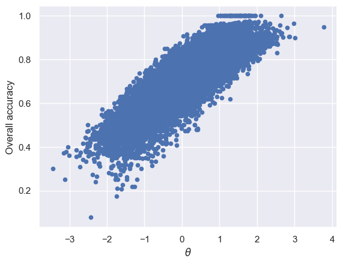

```python
ax = irt_subj_df.plot.scatter('theta', 'acc')
ax.set_xlabel('$\\theta$')
ax.set_ylabel('Overall accuracy')
```

Indeed, the model has learned a substantial positive correlation between ability and scores. Note that this is not a straight line, and that's a good thing. For instance, if a reader answered difficult questions correctly but made slip-ups on easier questions, the IRT model would determine that reader's ability ($\theta$) to be higher than other readers at the same test score.

Now, we return to the question at hand: what does the IRT discrimination $\alpha$ tell us about the Rust Book questions? One nice feature of the IRT model's fine-granularity is that we can sort the questions into interesting bins. Rather than looking at all questions sorted by $\alpha$, we can instead ask what the most discriminating questions are *at a given level of difficulty.* To do so, we first bin the questions into tertiles over $\beta$:

```python
def sigmoid(x):
    return 1 / (1 + math.exp(-x))

def plt_item(id):
    row = irt_df[irt_df.id == id].iloc[0]
    f = lambda theta: row['lambda'] + (1. - row['lambda']) * sigmoid(row['disc'] * (theta - row['diff']))
    xs = np.arange(-3., 3., 0.1)
    plt.figure(figsize=(3, 2))
    plt.plot(xs, [f(x) for x in xs])
    ax = plt.gca()
    ax.set_ylim(0., 1.)
    ax.set_xlabel('Ability')
    ax.set_ylabel('P(correct)')

tiles = [irt_df['diff'].quantile(0.33), irt_df['diff'].quantile(0.66)]
low_diff = irt_df[irt_df['diff'] < tiles[0]].sort_values('disc')
med_diff = irt_df[(tiles[0] < irt_df['diff']) & (irt_df['diff'] < tiles[1])].sort_values('disc')
high_diff = irt_df[tiles[1] < irt_df['diff']].sort_values('disc')
```

Then we can look at the highest $\alpha$ and lowest $\alpha$ questions in each tertile. This is the highest $\alpha$ in the bottom tertile, accompanied this time by its item characteristic curve:

```
ACCURACY 0.826
DISCRIMINATION 1.211
CORRELATION 0.341
QUESTION TYPE: Tracing
PROMPT:
fn f(x: i32) -> i32 { x + 1 }
fn main() {
  println!("{}", f({
    let y = 1;
    y + 1
  }));
}

ANSWER: DOES compile, stdout is:
  3
```

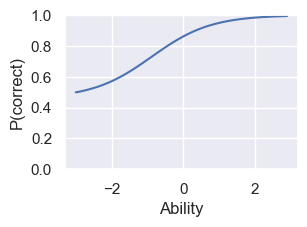

```python
row = low_diff.iloc[-1]
print(f'ACCURACY {row["acc"]:.3f}')
print(f'DISCRIMINATION {row["disc"]:.3f}')
print(f'CORRELATION {row["r"]:.3f}')
print_sch(row.id)
plt_item(row.id)
```

This question is easy (82% accuracy), but the ICC shows that it is a reasonably good discriminator between the lowest-ability readers and everyone else. For instance, this question could be useful as a part of a litmus test for screening out candidates with little to no knowledge of Rust.

By contrast, this next question is the lowest discrimination in the same tertile:

```
ACCURACY 0.632
DISCRIMINATION 0.148
CORRELATION 0.130
QUESTION TYPE: Tracing
PROMPT:
struct Point(i32, i32);
fn main() {
  let p = Point(1, 2);

  impl p {
    fn x(&self) -> i32 { self.0 }
  }

  println!("{}", p.x());
}

ANSWER: does NOT compile
```

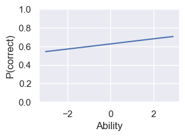

```python
row = low_diff.iloc[0]
print(f'ACCURACY {row["acc"]:.3f}')
print(f'DISCRIMINATION {row["disc"]:.3f}')
print(f'CORRELATION {row["r"]:.3f}')
print_sch(row.id)
plt_item(row.id)
```

Observe that the ICC is almost flat, meaning that even at high levels of ability, readers will not always get this question right. This is consistent with our earlier observation that "does not compile" questions tend to be low discrimination.

We can repeat this process by looking at the high/low $\alpha$ questions for the next two tertiles. High discrimination, medium tertile:

```
ACCURACY 0.531
DISCRIMINATION 0.714
CORRELATION 0.332
QUESTION TYPE: MultipleChoice
PROMPT:
The largest number representable by the type `i128` is:
✓ 2<sup>127</sup> - 1
✗ 2<sup>128</sup>
✗ 2<sup>128</sup> - 1
✗ 2<sup>127</sup>
```

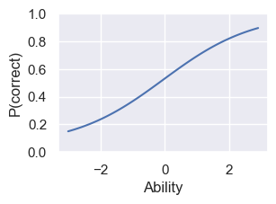

```python
row = med_diff.iloc[-1]
print(f'ACCURACY {row["acc"]:.3f}')
print(f'DISCRIMINATION {row["disc"]:.3f}')
print(f'CORRELATION {row["r"]:.3f}')
print_sch(row.id)
plt_item(row.id)
```

Low discrimination, medium tertile:

````
ACCURACY 0.674
DISCRIMINATION 0.039
CORRELATION 0.047
QUESTION TYPE: MultipleChoice
PROMPT:
The function `extract` is rejected by the borrow checker:

```rust
fn extract(b: &Box<i32>) -> i32 {
    let b2: Box<i32> = *b;
    *b2
}
```

Imagine that the borrow checker did not reject this function.
Determine whether there exists an input such that the function would cause undefined behavior if executed on that input.

✓ This function COULD cause undefined behavior
✗ This function could NOT cause undefined behavior
````

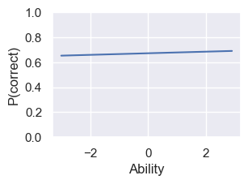

```python
row = med_diff.iloc[0]
print(f'ACCURACY {row["acc"]:.3f}')
print(f'DISCRIMINATION {row["disc"]:.3f}')
print(f'CORRELATION {row["r"]:.3f}')
print_sch(row.id)
plt_item(row.id)
```

High discrimination, high tertile:

````
ACCURACY 0.083
DISCRIMINATION 1.278
CORRELATION 0.055
QUESTION TYPE: MultipleChoice
PROMPT:
Say we have a function that moves a box, like this:
```
fn move_a_box(b: Box<i32>) {
  // This space intentionally left blank
}
```

Below are four snippets which are rejected by the Rust compiler.
Imagine that Rust instead allowed these snippets to compile and run.
Select each snippet that would cause undefined behavior, or select
"None of the above" if none of these snippets would cause undefined behavior.

✓ ```
let b = Box::new(0);
let b2 = b;
move_a_box(b);
```

✓ ```
let b = Box::new(0);
move_a_box(b);
println!("{}", b);
```

✓ ```
let b = Box::new(0);
move_a_box(b);
let b2 = b;
```

✗ ```
let b = Box::new(0);
let b2 = b;
println!("{}", b);
move_a_box(b2);
```

✗ None of the above
````

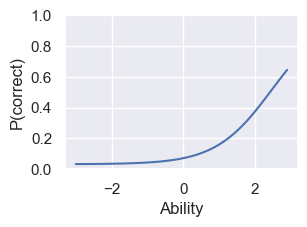

```python
row = high_diff.iloc[-2]
print(f'ACCURACY {row["acc"]:.3f}')
print(f'DISCRIMINATION {row["disc"]:.3f}')
print(f'CORRELATION {row["r"]:.3f}')
print_sch(row.id)
plt_item(row.id)
```

Note in this question that it has a low correlation ($r = 0.055$) in part because of its difficulty. If we just used correlation-based discrimination, we may overlook or even delete items like this. But the IRT model reveals that at a given level of difficulty, this item is actually quite discriminative between the highest-ability readers and everyone else.

Low discrimination, high tertile:

````
ACCURACY 0.450
DISCRIMINATION 0.050
CORRELATION 0.013
QUESTION TYPE: ShortAnswer
PROMPT:
Imagine using a third-party function whose implementation you don't know, but whose type signature is this:

```
fn mystery<T>(x: T) -> T {
  // ????
}
```

Then you call `mystery` like this:

```
let y = mystery(3);
```

Assuming `mystery` uses no unsafe code, then the value of `y` must be :

ANSWER: 3
````

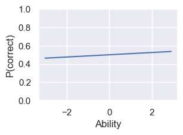

```python
row = high_diff.iloc[0]
print(f'ACCURACY {row["acc"]:.3f}')
print(f'DISCRIMINATION {row["disc"]:.3f}')
print(f'CORRELATION {row["r"]:.3f}')
print_sch(row.id)
plt_item(row.id)
```

## 3 Application: Test Construction

As mentioned before, one application for these statistics is test construction. The Rust Book provides too large a pool of items to give on a single exam, but we can use these statistics to identify a small subset of questions that would be useful in discriminating between participants. We demonstrate three possible purposes and means of test construction.

### 3.1 Maximal Correlation Subset

One metric for test construction is to find a set of items whose average score is maximally correlated with overall test performance. In theory, performance on this test would be the best possible indicator for someone's overall performance on all the questions in the Rust Book.

A brute-force method is to find the maximum among all subsets of size $N$. For our dataset with a decently-optimized Rust implementation, the largest $N$ that finishes in under a day on a 2021 M1 Macbook Pro is $N = 5$.

> Note: still need to run $N = 5$. Only have data up to $N = 4$ right now.

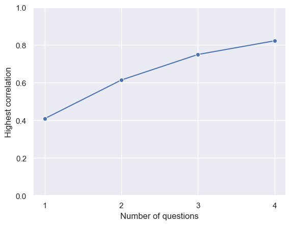

```python
max_N = 4
discrim_subsets = [
    pd.read_json(f'../data/discrim-subset-{i}.json') for i in range(1, max_N + 1)
]

x = list(range(1, max_N + 1))
y = [df.r.max() for df in discrim_subsets]
ax = sns.lineplot(x=x, y=y, marker="o")
ax.set_xticks(x)
ax.set_ylim(0, 1)
ax.set_xlabel('Number of questions')
_ = ax.set_ylabel('Highest correlation')
```

At $N = 4$, the maximum correlation is $r = 0.82$. This corresponds to the following 4 questions:

```python
for q in discrim_subsets[max_N - 1].qs.iloc[0]:
    print_sch(q)
    utils.print_sep()
```

````
QUESTION TYPE: MultipleChoice
PROMPT:
Consider these two methods that increment a field of a struct. Which style would be more idiomatic for Rust?

```
struct Point(i32, i32);
impl Point {
  fn incr_v1(mut self)  { self.0 += 1; }
  fn incr_v2(&mut self) { self.0 += 1; }
}
```

✓ `incr_v2`
✗ `incr_v1`
✗ Both are idiomatic
✗ Neither are idiomatic

====================

QUESTION TYPE: MultipleChoice
PROMPT:
Which of the following are valid reasons for implementing a macro as a
procedural macro instead of a declarative macro?

✓ You want to integrate with Rust's derive system
✓ Your macro requires nontrivial analysis of the macro user's syntax
✗ You want to generate variable-length sequences of code
✗ Your macro requires an entire item as input, not just an expression

====================

QUESTION TYPE: MultipleChoice
PROMPT:
At the end of this function, Rust will call `drop` on which variables:
```
fn main() {
  let s1 = String::from("a");
  let s2 = String::from("b");
  let s3 = s2;
}
```

✓ `s1` and `s3`
✗ `s1`, `s2`, and `s3`
✗ `s2` and `s3`
✗ `s3`

====================

QUESTION TYPE: ShortAnswer
PROMPT:
What is the name of the command-line tool for managing the version of Rust on your machine?
ANSWER: rustup

====================
````

### 3.2 Targeted IRT Discriminators

Another possible use case is that we want to specifically distinguish between people at a particular skill level. For instance, we might want an "easy" test to check if people have basic experience with Rust, or a "hard" test to find only highly-qualified Rustaceans. We can use the IRT model to sample discriminative questions at a given level of difficulty. For example, an easy test would look like this:

```python
for id in low_diff.sort_values('disc', ascending=False).iloc[:max_N].id:
    print_sch(id)
    utils.print_sep()
```

````
QUESTION TYPE: Tracing
PROMPT:
fn f(x: i32) -> i32 { x + 1 }
fn main() {
  println!("{}", f({
    let y = 1;
    y + 1
  }));
}

ANSWER: DOES compile, stdout is:
  3

====================

QUESTION TYPE: MultipleChoice
PROMPT:
Let's say you have the following program in a file `hello.rs`:

```
fn main() {
  println!("Hello world!");
}
```

Say you then run the command `rustc hello.rs` from the command-line. Which statement best describes what happens next?

✓ `rustc` generates a binary executable named `hello`
✗ `rustc` will print an error because this is an invalid program
✗ `rustc` executes the program and prints out `Hello world!`
✗ `rustc` reformats `hello.rs` according to the Rust style guide

====================

QUESTION TYPE: ShortAnswer
PROMPT:
Every executable Rust program must contain a function with the name:
ANSWER: main

====================
````

[output cut: 17 more lines]

````
  } else if n == 1 {
    None
  } else {
    Some(n - 2)
  }
}
```

The functions have the same behavior for:

✓ All inputs
✗ No inputs
✗ Some, but not all inputs

====================
````

And a hard test looks like this:

```python
for id in high_diff.sort_values('disc', ascending=False).iloc[:max_N].id:
    print_sch(id)
    utils.print_sep()
```

````
QUESTION TYPE: ShortAnswer
PROMPT:
Consider a program with the following unit test:

```
#[test]
fn test_the_logger() { /* ... */ }

#[test]
fn test_the_database() { /* ... */ }

#[test]
fn test_logger_and_database() { /* ... */ }
```

What is the *shortest* string you can pass to `cargo test <the_string>` such that *only* `test_the_logger` and `test_the_database` are executed?

ANSWER: h

====================

QUESTION TYPE: MultipleChoice
PROMPT:
Say we have a function that moves a box, like this:
```
fn move_a_box(b: Box<i32>) {
  // This space intentionally left blank
}
```

Below are four snippets which are rejected by the Rust compiler.
Imagine that Rust instead allowed these snippets to compile and run.
Select each snippet that would cause undefined behavior, or select
"None of the above" if none of these snippets would cause undefined behavior.

✓ ```
let b = Box::new(0);
let b2 = b;
move_a_box(b);
```
````

[output cut: 84 more lines]

````
  }
}

fn main() {
  use parent::{*, child as alias};
  // ...
}
```

Inside `main`, what is the total number of paths that can refer to `a`, `b`, or `c` (not including those that use `self`, `super`, or `crate`)?
Write your answer as a digit such as 0 or 1. For example, if the only two valid paths were `a` and `parent::b`, then the answer would be 2.

ANSWER: 5

====================
````